# Run PLIER on test compendium

J. Taroni for CCDL

2019

Do we “get more biology” out of the combined technology test compendium than we get out of each of the technologies individually?

We’ll use the metrics we developed as part of the MultiPLIER project here. Specifically, do we get higher pathway coverage for a model trained on the dual-technology test compendium vs. those trained on the individual technology compendia?

## Setup

### Libraries

```r
# PLIER installation
# BiocManager::install("qvalue", update = FALSE)
# devtools::install_github('wgmao/PLIER',
#                          ref = 'a2d4a2aa343f9ed4b9b945c04326bebd31533d4d',
#                          dependencies = TRUE)
# install.packages("cowplot")
```

```r
library(PLIER)
library(org.Dr.eg.db)
```

### Functions

```r
`%>%` <- dplyr::`%>%`
```

Source the most recent version of the MultiPLIER utils from Github

```r
source("https://github.com/greenelab/multi-plier/raw/7c56a2867f9f08f7bcd3617875c7c2dbe886cbeb/util/plier_util.R")
# we only want GetPathwayCoverage
rm(list = setdiff(ls(), "GetPathwayCoverage"))
```

```r
# we'll train 3 PLIER models: matrix with both technologies, microarray samples
# only, and RNA-seq samples only
PLIER_wrapper <- function(exprs_mat, common_genes, pathway_mat, seed = 123) {

  # set seed for reproducibility
  set.seed(seed)

  # z-score the expression data
  row_norm_exprs <- PLIER::rowNorm(exprs_mat[common_genes, ])

  # how many "significant PCs" via the elbow method -- we use this to set k when
  # training a PLIER model
  num_pcs <- PLIER::num.pc(row_norm_exprs)

  return(PLIER::PLIER(data = row_norm_exprs[common_genes, ],
                      priorMat = pathway_mat[common_genes, ],
                      k = round(num_pcs * 1.3)))
}
```

```r
# wrapper function for running PLIER repeatedly with different seeds that are
# supplied through the seeds vector
get_plier_list <- function(exprs_mat, common_genes, pathway_mat,
                           seeds) {
  lapply(seeds,
         function(x) PLIER_wrapper(exprs_mat = exprs_mat,
                                   common_genes = common_genes,
                                   pathway_mat = combine_path_mat,
                                   seed = x)
  )
}
```

These functions are specifically for use with the lists of PLIER models that are returned from `get_plier_list`.

```r
# get pathway coverage metrics for each model in the list into a data.frame
get_pathway_df <- function(plier_list) {
  reshape2::melt(lapply(plier_list, GetPathwayCoverage))
}
```

```r
# get a data.frame of the number of latent variables in each model
get_num_lvs_df <- function(plier_list, technology = "all") {
  # technology will be the label used in the 'technology' label
  reshape2::melt(lapply(plier_list, function(x) nrow(x$B))) %>%
    dplyr::mutate(seed = L1, metric = rep("Number of LVs",
                                          length(plier_list)),
                  technology = rep(technology, length(plier_list))) %>%
    dplyr::select(-L1)
}
```

### Directories

```r
pathway_dir <- file.path("data", "pathways")
result_dir <- "results"
plot_dir <- "plots"
```

Results directory specifically for holding the PLIER models

```r
plier_result_dir <- file.path(result_dir, "PLIER_models")
dir.create(plier_result_dir, showWarnings = FALSE, recursive = TRUE)
```

## Read in data

### Prior information matrices

We need to get the 3 pathway prior information matrices we have: developmental stage, tissues (based on adult only), and the wikipathways into a single matrix. We can do this with the `PLIER::combinePaths` function.

```r
# read in the three individual matrices we prepped in
# 09-prior_information_matrix
wikipathway_mat <- readRDS(file.path(pathway_dir,
                                     "Danio_rerio_wikipathways_prior_info.RDS"))
adult_tissue_mat <- readRDS(file.path(pathway_dir,
                                      "ZFIN_adult_tissue_prior_info.RDS"))
dev_stage_mat <- readRDS(file.path(pathway_dir,
                                   "ZFIN_stages_prior_info.RDS"))
# combine into a single matrix for use with PLIER
combine_path_mat <- PLIER::combinePaths(adult_tissue_mat,
                                        dev_stage_mat,
                                        wikipathway_mat)
# we no longer need the individual matrices
rm(adult_tissue_mat, dev_stage_mat, wikipathway_mat)
```

### Test compendium

We need to convert the test compendium gene identifiers from Ensembl gene IDs to ZFIN identifiers so that the IDs in the prior information and the expression data match.

```r
# first we need to read in the
exprs_file <- file.path("data", "larger_compendium_exprs_mat.RDS")
exprs_mat <- readRDS(exprs_file)
```

We expect that there will be a 1:many mapping here, so we’ll use the option where only the first thing that comes back is returned by setting `multiVals = "first"` (note that this is the default behavior).

```r
# ENSDARG -> ZDB-GENE
zfin_ids <- mapIds(org.Dr.eg.db, keys = rownames(exprs_mat),
                   column = "ZFIN", keytype = "ENSEMBL",
                   multiVals = "first")
# these should be in the same order, but out of an abundance of caution!
if (all.equal(rownames(exprs_mat), names(zfin_ids))) {
  rownames(exprs_mat) <- zfin_ids
} else {
  stop("Something went wrong!")
}
```

## PLIER

We’re going to do five repeats.

```r
set.seed(123)
seeds <- sample(1:100000, 5)
names(seeds) <- seeds
```

### Both technologies

```r
# find the common genes between the expression matrix and the prior information
# matrix
common_genes <- PLIER::commonRows(exprs_mat, combine_path_mat)
# this expression matrix includes samples from both technologies
both_tech_plier_list <- get_plier_list(exprs_mat = exprs_mat,
                                       common_genes = common_genes,
                                       pathway_mat = combine_path_mat,
                                       seeds = seeds)
```

```
Using rsvd: set seed for consistent results
Removing 384 pathways with too few genesComputing SVD
Using rsvd: set seed for consistent results
Done
```

```
[1] 102.307
[1] "L2 is set to 102.30700707417"
[1] "L1 is set to 51.1535035370849"
```

```
errorY (SVD based:best possible) = 0.1191
Updating L3, current fraction= 0, target=0.7
Updating L3, current fraction= 0.6549, target=0.7
Updating L3, current fraction= 0.6965, target=0.7
Updating L3, current fraction= 0.6757, target=0.7
Updating L3, current fraction= 0.6923, target=0.7
Updating L3, current fraction= 0.7006, target=0.7
L3 not changed
Updating L3, current fraction= 0.6923, target=0.7
Updating L3, current fraction= 0.7048, target=0.7
Updating L3, current fraction= 0.6985, target=0.7
L3 not changed
Updating L3, current fraction= 0.7089, target=0.7
Updating L3, current fraction= 0.6965, target=0.7
Updating L3, current fraction= 0.7048, target=0.7
Updating L3, current fraction= 0.6881, target=0.7
Updating L3, current fraction= 0.6923, target=0.7
Updating L3, current fraction= 0.7006, target=0.7
L3 not changed
Updating L3, current fraction= 0.6985, target=0.7
L3 not changed
Bdiff is not decreasing
Bdiff is not decreasing
Bdiff is not decreasing
Bdiff is not decreasing
Bdiff is not decreasing
Updating L3, current fraction= 0.6923, target=0.7
Bdiff is not decreasing
converged at  iteration 340 Bdiff is not decreasing
There are 187  LVs with AUC>0.70
Using rsvd: set seed for consistent results
Removing 384 pathways with too few genesComputing SVD
Using rsvd: set seed for consistent results
Done
```

```
[1] 102.307
[1] "L2 is set to 102.307006195089"
[1] "L1 is set to 51.1535030975444"
```

```
errorY (SVD based:best possible) = 0.1191
Updating L3, current fraction= 0, target=0.7
Updating L3, current fraction= 0.6216, target=0.7
Updating L3, current fraction= 0.6965, target=0.7
Updating L3, current fraction= 0.6694, target=0.7
Updating L3, current fraction= 0.7173, target=0.7
Updating L3, current fraction= 0.6985, target=0.7
L3 not changed
Updating L3, current fraction= 0.6944, target=0.7
Updating L3, current fraction= 0.6881, target=0.7
Updating L3, current fraction= 0.7027, target=0.7
Updating L3, current fraction= 0.6819, target=0.7
Updating L3, current fraction= 0.6965, target=0.7
Updating L3, current fraction= 0.6965, target=0.7
Updating L3, current fraction= 0.6944, target=0.7
Updating L3, current fraction= 0.6944, target=0.7
Updating L3, current fraction= 0.7027, target=0.7
Updating L3, current fraction= 0.7089, target=0.7
Bdiff is not decreasing
Bdiff is not decreasing
Bdiff is not decreasing
Updating L3, current fraction= 0.7048, target=0.7
Bdiff is not decreasing
Bdiff is not decreasing
Bdiff is not decreasing
converged at  iteration 342 Bdiff is not decreasing
There are 157  LVs with AUC>0.70
Using rsvd: set seed for consistent results
Removing 384 pathways with too few genesComputing SVD
Using rsvd: set seed for consistent results
Done
```

```
[1] 102.307
[1] "L2 is set to 102.307008634339"
[1] "L1 is set to 51.1535043171697"
```

```
errorY (SVD based:best possible) = 0.1191
Updating L3, current fraction= 0, target=0.7
Updating L3, current fraction= 0.6653, target=0.7
Updating L3, current fraction= 0.6881, target=0.7
Updating L3, current fraction= 0.6798, target=0.7
Updating L3, current fraction= 0.6965, target=0.7
Updating L3, current fraction= 0.6902, target=0.7
Updating L3, current fraction= 0.711, target=0.7
Updating L3, current fraction= 0.7006, target=0.7
L3 not changed
Updating L3, current fraction= 0.6944, target=0.7
Updating L3, current fraction= 0.7006, target=0.7
L3 not changed
Updating L3, current fraction= 0.6881, target=0.7
Updating L3, current fraction= 0.7193, target=0.7
Updating L3, current fraction= 0.7027, target=0.7
Updating L3, current fraction= 0.6923, target=0.7
Updating L3, current fraction= 0.6965, target=0.7
Updating L3, current fraction= 0.6778, target=0.7
Updating L3, current fraction= 0.6902, target=0.7
There are 174  LVs with AUC>0.70
Using rsvd: set seed for consistent results
Removing 384 pathways with too few genesComputing SVD
Using rsvd: set seed for consistent results
Done
```

```
[1] 102.307
[1] "L2 is set to 102.307007828167"
[1] "L1 is set to 51.1535039140833"
```

```
errorY (SVD based:best possible) = 0.1191
Updating L3, current fraction= 0, target=0.7
Updating L3, current fraction= 0.6279, target=0.7
Updating L3, current fraction= 0.6778, target=0.7
Updating L3, current fraction= 0.6985, target=0.7
L3 not changed
Updating L3, current fraction= 0.6923, target=0.7
Updating L3, current fraction= 0.6902, target=0.7
Updating L3, current fraction= 0.7006, target=0.7
L3 not changed
Updating L3, current fraction= 0.7089, target=0.7
Updating L3, current fraction= 0.6902, target=0.7
Updating L3, current fraction= 0.6985, target=0.7
L3 not changed
Updating L3, current fraction= 0.7069, target=0.7
Updating L3, current fraction= 0.6881, target=0.7
Updating L3, current fraction= 0.6944, target=0.7
Updating L3, current fraction= 0.6881, target=0.7
Updating L3, current fraction= 0.7131, target=0.7
Updating L3, current fraction= 0.6944, target=0.7
Bdiff is not decreasing
Bdiff is not decreasing
Bdiff is not decreasing
Bdiff is not decreasing
Bdiff is not decreasing
Bdiff is not decreasing
converged at  iteration 337 Bdiff is not decreasing
There are 163  LVs with AUC>0.70
Using rsvd: set seed for consistent results
Removing 384 pathways with too few genesComputing SVD
Using rsvd: set seed for consistent results
Done
```

```
[1] 102.307
[1] "L2 is set to 102.307008614146"
[1] "L1 is set to 51.1535043070729"
```

```
errorY (SVD based:best possible) = 0.1191
Updating L3, current fraction= 0, target=0.7
Updating L3, current fraction= 0.6528, target=0.7
Updating L3, current fraction= 0.6736, target=0.7
Updating L3, current fraction= 0.7048, target=0.7
Updating L3, current fraction= 0.6819, target=0.7
Updating L3, current fraction= 0.7297, target=0.7
Updating L3, current fraction= 0.6923, target=0.7
Updating L3, current fraction= 0.6923, target=0.7
Updating L3, current fraction= 0.7006, target=0.7
L3 not changed
Updating L3, current fraction= 0.7069, target=0.7
Updating L3, current fraction= 0.6965, target=0.7
Updating L3, current fraction= 0.7048, target=0.7
Updating L3, current fraction= 0.6861, target=0.7
Updating L3, current fraction= 0.7027, target=0.7
Updating L3, current fraction= 0.6944, target=0.7
Updating L3, current fraction= 0.7006, target=0.7
L3 not changed
Updating L3, current fraction= 0.7006, target=0.7
L3 not changed
There are 169  LVs with AUC>0.70
```

Check the pathway coverage for these models

```r
both_tech_pathway_coverage <- get_pathway_df(both_tech_plier_list)
```

### Microarray only

```r
microarray_mat <- exprs_mat[, -grep("SRR|ERR|DRR", colnames(exprs_mat))]
microarray_plier_list <- get_plier_list(exprs_mat = microarray_mat,
                                        common_genes = common_genes,
                                        pathway_mat = combine_path_mat,
                                        seeds = seeds)
```

```
Using rsvd: set seed for consistent results
Removing 384 pathways with too few genesComputing SVD
Using rsvd: set seed for consistent results
Done
```

```
[1] 51.51017
[1] "L2 is set to 51.5101693139858"
[1] "L1 is set to 25.7550846569929"
```

```
errorY (SVD based:best possible) = 0.0399
Updating L3, current fraction= 0, target=0.7
Updating L3, current fraction= 0.6522, target=0.7
Updating L3, current fraction= 0.7295, target=0.7
Updating L3, current fraction= 0.715, target=0.7
Updating L3, current fraction= 0.7391, target=0.7
Updating L3, current fraction= 0.6908, target=0.7
Updating L3, current fraction= 0.7053, target=0.7
Updating L3, current fraction= 0.7053, target=0.7
Bdiff is not decreasing
Bdiff is not decreasing
Bdiff is not decreasing
Bdiff is not decreasing
Updating L3, current fraction= 0.6908, target=0.7
Bdiff is not decreasing
Bdiff is not decreasing
converged at  iteration 181 Bdiff is not decreasing
There are 77  LVs with AUC>0.70
Using rsvd: set seed for consistent results
Removing 384 pathways with too few genesComputing SVD
Using rsvd: set seed for consistent results
Done
```

```
[1] 51.51021
[1] "L2 is set to 51.5102127346538"
[1] "L1 is set to 25.7551063673269"
```

```
errorY (SVD based:best possible) = 0.0399
Updating L3, current fraction= 0, target=0.7
Updating L3, current fraction= 0.6812, target=0.7
Updating L3, current fraction= 0.744, target=0.7
Updating L3, current fraction= 0.6715, target=0.7
Updating L3, current fraction= 0.715, target=0.7
Updating L3, current fraction= 0.7198, target=0.7
Updating L3, current fraction= 0.7101, target=0.7
Bdiff is not decreasing
Bdiff is not decreasing
Bdiff is not decreasing
Bdiff is not decreasing
Bdiff is not decreasing
Bdiff is not decreasing
converged at  iteration 159 Bdiff is not decreasing
There are 75  LVs with AUC>0.70
Using rsvd: set seed for consistent results
Removing 384 pathways with too few genesComputing SVD
Using rsvd: set seed for consistent results
Done
```

```
[1] 51.51029
[1] "L2 is set to 51.5102852207211"
[1] "L1 is set to 25.7551426103605"
```

```
errorY (SVD based:best possible) = 0.0399
Updating L3, current fraction= 0, target=0.7
Updating L3, current fraction= 0.6812, target=0.7
Updating L3, current fraction= 0.7343, target=0.7
Updating L3, current fraction= 0.6618, target=0.7
Updating L3, current fraction= 0.6908, target=0.7
Updating L3, current fraction= 0.7198, target=0.7
Updating L3, current fraction= 0.686, target=0.7
Updating L3, current fraction= 0.7005, target=0.7
L3 not changed
Updating L3, current fraction= 0.6957, target=0.7
L3 not changed
Bdiff is not decreasing
Bdiff is not decreasing
Bdiff is not decreasing
Bdiff is not decreasing
Bdiff is not decreasing
Bdiff is not decreasing
converged at  iteration 199 Bdiff is not decreasing
There are 74  LVs with AUC>0.70
Using rsvd: set seed for consistent results
Removing 384 pathways with too few genesComputing SVD
Using rsvd: set seed for consistent results
Done
```

```
[1] 51.51042
[1] "L2 is set to 51.5104158351411"
[1] "L1 is set to 25.7552079175705"
```

```
errorY (SVD based:best possible) = 0.0399
Updating L3, current fraction= 0, target=0.7
Updating L3, current fraction= 0.7053, target=0.7
Updating L3, current fraction= 0.7053, target=0.7
Updating L3, current fraction= 0.7053, target=0.7
Updating L3, current fraction= 0.7101, target=0.7
Bdiff is not decreasing
Updating L3, current fraction= 0.6957, target=0.7
L3 not changed
Bdiff is not decreasing
Bdiff is not decreasing
Bdiff is not decreasing
Bdiff is not decreasing
Bdiff is not decreasing
converged at  iteration 124 Bdiff is not decreasing
There are 72  LVs with AUC>0.70
Using rsvd: set seed for consistent results
Removing 384 pathways with too few genesComputing SVD
Using rsvd: set seed for consistent results
Done
```

```
[1] 51.50968
[1] "L2 is set to 51.5096780951195"
[1] "L1 is set to 25.7548390475598"
```

```
errorY (SVD based:best possible) = 0.0399
Updating L3, current fraction= 0, target=0.7
Updating L3, current fraction= 0.6522, target=0.7
Updating L3, current fraction= 0.7343, target=0.7
Updating L3, current fraction= 0.715, target=0.7
Updating L3, current fraction= 0.7101, target=0.7
Updating L3, current fraction= 0.7005, target=0.7
L3 not changed
Updating L3, current fraction= 0.7005, target=0.7
L3 not changed
Bdiff is not decreasing
Bdiff is not decreasing
Bdiff is not decreasing
Bdiff is not decreasing
Bdiff is not decreasing
Bdiff is not decreasing
converged at  iteration 158 Bdiff is not decreasing
There are 82  LVs with AUC>0.70
```

```r
microarray_pathway_coverage <- get_pathway_df(microarray_plier_list)
```

### RNA-seq only

```r
rnaseq_mat <- exprs_mat[, grep("SRR|ERR|DRR", colnames(exprs_mat))]
rnaseq_plier_list <- get_plier_list(exprs_mat = rnaseq_mat,
                                  common_genes = common_genes,
                                  pathway_mat = combine_path_mat,
                                  seeds = seeds)
```

```
Using rsvd: set seed for consistent results
Removing 384 pathways with too few genesComputing SVD
Using rsvd: set seed for consistent results
Done
```

```
[1] 96.87496
[1] "L2 is set to 96.8749607315051"
[1] "L1 is set to 48.4374803657525"
```

```
errorY (SVD based:best possible) = 0.1334
Updating L3, current fraction= 0, target=0.7
Updating L3, current fraction= 0.6079, target=0.7
Updating L3, current fraction= 0.6853, target=0.7
Updating L3, current fraction= 0.6942, target=0.7
Updating L3, current fraction= 0.6835, target=0.7
Updating L3, current fraction= 0.6853, target=0.7
Updating L3, current fraction= 0.7068, target=0.7
Updating L3, current fraction= 0.6906, target=0.7
Updating L3, current fraction= 0.6871, target=0.7
Updating L3, current fraction= 0.705, target=0.7
Updating L3, current fraction= 0.6978, target=0.7
Updating L3, current fraction= 0.696, target=0.7
Updating L3, current fraction= 0.7068, target=0.7
Updating L3, current fraction= 0.7104, target=0.7
Updating L3, current fraction= 0.6924, target=0.7
Updating L3, current fraction= 0.6924, target=0.7
converged at  iteration 336
There are 170  LVs with AUC>0.70
Using rsvd: set seed for consistent results
Removing 384 pathways with too few genesComputing SVD
Using rsvd: set seed for consistent results
Done
```

```
[1] 96.87505
[1] "L2 is set to 96.8750539482002"
[1] "L1 is set to 48.4375269741001"
```

```
errorY (SVD based:best possible) = 0.1334
Updating L3, current fraction= 0, target=0.7
Updating L3, current fraction= 0.6259, target=0.7
Updating L3, current fraction= 0.6475, target=0.7
Updating L3, current fraction= 0.6853, target=0.7
Updating L3, current fraction= 0.6924, target=0.7
Updating L3, current fraction= 0.7014, target=0.7
L3 not changed
Updating L3, current fraction= 0.6817, target=0.7
Updating L3, current fraction= 0.6996, target=0.7
L3 not changed
Updating L3, current fraction= 0.6871, target=0.7
Updating L3, current fraction= 0.6888, target=0.7
Updating L3, current fraction= 0.7158, target=0.7
Updating L3, current fraction= 0.705, target=0.7
Updating L3, current fraction= 0.7032, target=0.7
Updating L3, current fraction= 0.6906, target=0.7
Updating L3, current fraction= 0.7032, target=0.7
converged at  iteration 303
There are 171  LVs with AUC>0.70
Using rsvd: set seed for consistent results
Removing 384 pathways with too few genesComputing SVD
Using rsvd: set seed for consistent results
Done
```

```
[1] 96.87501
[1] "L2 is set to 96.875006257905"
[1] "L1 is set to 48.4375031289525"
```

```
errorY (SVD based:best possible) = 0.1334
Updating L3, current fraction= 0, target=0.7
Updating L3, current fraction= 0.6025, target=0.7
Updating L3, current fraction= 0.6763, target=0.7
Updating L3, current fraction= 0.6871, target=0.7
Updating L3, current fraction= 0.6673, target=0.7
Updating L3, current fraction= 0.6924, target=0.7
Updating L3, current fraction= 0.6853, target=0.7
Updating L3, current fraction= 0.696, target=0.7
Updating L3, current fraction= 0.6996, target=0.7
L3 not changed
Updating L3, current fraction= 0.7032, target=0.7
Updating L3, current fraction= 0.6853, target=0.7
Updating L3, current fraction= 0.7104, target=0.7
Updating L3, current fraction= 0.705, target=0.7
Updating L3, current fraction= 0.6906, target=0.7
Updating L3, current fraction= 0.696, target=0.7
converged at  iteration 316
There are 194  LVs with AUC>0.70
Using rsvd: set seed for consistent results
Removing 384 pathways with too few genesComputing SVD
Using rsvd: set seed for consistent results
Done
```

```
[1] 113.1394
[1] "L2 is set to 113.139389893765"
[1] "L1 is set to 56.5696949468825"
```

```
errorY (SVD based:best possible) = 0.1588
Updating L3, current fraction= 0, target=0.7
Updating L3, current fraction= 0.6129, target=0.7
Updating L3, current fraction= 0.6979, target=0.7
L3 not changed
Updating L3, current fraction= 0.6979, target=0.7
L3 not changed
Updating L3, current fraction= 0.7038, target=0.7
Updating L3, current fraction= 0.7009, target=0.7
L3 not changed
Updating L3, current fraction= 0.6745, target=0.7
Updating L3, current fraction= 0.7067, target=0.7
Updating L3, current fraction= 0.695, target=0.7
Updating L3, current fraction= 0.6921, target=0.7
Updating L3, current fraction= 0.6979, target=0.7
L3 not changed
Bdiff is not decreasing
Bdiff is not decreasing
Updating L3, current fraction= 0.7126, target=0.7
Bdiff is not decreasing
Bdiff is not decreasing
Bdiff is not decreasing
Bdiff is not decreasing
converged at  iteration 243 Bdiff is not decreasing
There are 124  LVs with AUC>0.70
Using rsvd: set seed for consistent results
Removing 384 pathways with too few genesComputing SVD
Using rsvd: set seed for consistent results
Done
```

```
[1] 96.875
[1] "L2 is set to 96.8749981036591"
[1] "L1 is set to 48.4374990518296"
```

```
errorY (SVD based:best possible) = 0.1334
Updating L3, current fraction= 0, target=0.7
Updating L3, current fraction= 0.6421, target=0.7
Updating L3, current fraction= 0.6547, target=0.7
Updating L3, current fraction= 0.6853, target=0.7
Updating L3, current fraction= 0.696, target=0.7
Updating L3, current fraction= 0.6817, target=0.7
Updating L3, current fraction= 0.6871, target=0.7
Updating L3, current fraction= 0.714, target=0.7
Updating L3, current fraction= 0.6853, target=0.7
Updating L3, current fraction= 0.7086, target=0.7
Updating L3, current fraction= 0.6835, target=0.7
Updating L3, current fraction= 0.6996, target=0.7
L3 not changed
Updating L3, current fraction= 0.6996, target=0.7
L3 not changed
Updating L3, current fraction= 0.7032, target=0.7
Updating L3, current fraction= 0.6835, target=0.7
Bdiff is not decreasing
Bdiff is not decreasing
Bdiff is not decreasing
Bdiff is not decreasing
Bdiff is not decreasing
Updating L3, current fraction= 0.7068, target=0.7
Bdiff is not decreasing
Bdiff is not decreasing
Bdiff is not decreasing
converged at  iteration 322 Bdiff is not decreasing
There are 169  LVs with AUC>0.70
```

```r
rnaseq_pathway_coverage <- get_pathway_df(rnaseq_plier_list)
```

#### Wrangle pathway coverage results

And write to file

```r
coverage_df <- dplyr::bind_rows(list(
  "all" = both_tech_pathway_coverage,
  "microarray" = microarray_pathway_coverage,
  "rnaseq"= rnaseq_pathway_coverage),
  .id = "technology"
) %>%
  dplyr::mutate(metric = L2, seed = L1) %>%
  dplyr::select(c(-L2, -L1)) %>%
  dplyr::filter(metric != "sig.pathway.by.lv") %>%
  dplyr::mutate(metric = dplyr::case_when(
    metric == "pathway" ~ "Pathway Coverage",
    metric == "lv" ~ "LV Proportion"
  ))
```

Number of latent variables

```r
num_lvs_df <- dplyr::bind_rows(
  "all" = get_num_lvs_df(both_tech_plier_list),
  "microarray" = get_num_lvs_df(microarray_plier_list, "microarray"),
  "rnaseq" = get_num_lvs_df(rnaseq_plier_list, "rnaseq")
)
coverage_df <- coverage_df %>%
  dplyr::bind_rows(num_lvs_df)
readr::write_tsv(coverage_df,
                 file.path(result_dir,
                           "larger_compendium_pathway_coverage.tsv"))
```

#### Save models to file

```r
saveRDS(both_tech_plier_list,
        file = file.path(plier_result_dir,
                         "larger_both_technologies_PLIER_list.RDS"))
saveRDS(microarray_plier_list,
        file = file.path(plier_result_dir,
                         "larger_microarray_PLIER_list.RDS"))
saveRDS(rnaseq_plier_list,
        file = file.path(plier_result_dir, "larger_rnaseq_PLIER_list.RDS"))
```

## Plotting

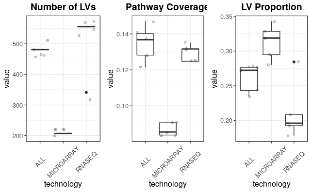

```r
# these metrics are on different scales, so we'll plot them separately and
# then assemble them into a single, multipanel plot
plot_list <-
  lapply(c("Number of LVs", "Pathway Coverage", "LV Proportion"),
         function(x)
           coverage_df %>%
           dplyr::mutate(technology = toupper(technology)) %>%
           dplyr::filter(metric == x) %>%
           ggplot2::ggplot(ggplot2::aes(x = technology, y = value)) +
           ggplot2::geom_boxplot() +
           ggplot2::geom_jitter(alpha = 0.2) +
           ggplot2::theme_bw() +
           ggplot2::ggtitle(x) +
           ggplot2::theme(plot.title = ggplot2::element_text(hjust = 0.5,
                                                             face = "bold"),
                          text = ggplot2::element_text(size = 12),
                          axis.text.x = ggplot2::element_text(
                            angle = 45, vjust = 0.5
                          )))
cowplot::plot_grid(plotlist = plot_list, ncol = 3)
```

```r
ggplot2::ggsave(file.path(plot_dir,
                          "larger_compendium_plier_metrics_by_tech.png"),
                height = 8.5, width = 11,
                plot = ggplot2::last_plot())
```